# Taller 2 en grupo 1.5 puntos nota final

Estadística

09 enero, 2023

Nombre del grupo: PMJP

Autores

1. Florit Ensenyat, Jordi
2. Girón Rodríguez, Pau
3. Fornés Reynés, Josep Gabriel
4. Ferrer Fernández, Marc

**INSTRUCCIONES**

Comentarios:

- Para hacer los cálculos solicitados en los apartados anterior se deben eliminar los valores no disponibles (`NA`) de las variables.
- Siempre que sea posible se deben utilizar las funciones de R explicadas en clase para resolver los ejercicios.
- Debe redactar un documento utilizando Rmarkdown con las respuestas a estas preguntas y que incluya el código R utilizado. También debe generar (Knit) una versión HTML del documento.

El documento, en formato .Rmd y .html o .pdf , se debe **entregar a Aula Digital antes del 22 de diciembre**.

# 1 Parte 1. Descripción de datos tidyverse

Considera el conjunto de datos `examenes.csv` que contiene las siguientes variables:

- `gender`: sexo del estudiante masculino (“male”) o femenino (“female”).
- `race/ethnicity`: raza del estudiante (grupos desde el A hasta el E).
- `parental level of education`: nivel educativo de los padres desde algo de estudios secundarios (“some high school”) hasta master (“master degree”).
- `lunch`: tipo de precio que paga el estudiante por la comida que recibe en el centro educativo: normal (“standard”) o con descuento (“free/reduced”).
- `test preparation course`: si el estudiante ha tomado un curso de preparación para el examen de acceso a la Universidad, dos posibles valores: lo completó (“completed”), no lo tomó (“none”).
- `math score`: nota que obtuvo el estudiante en la parte de matemáticas del examen de acceso a la Universidad. Valores del 0 al 100, donde el 100 es la máxima puntuación.
- `reading score`: nota que obtuvo el estudiante en la parte de lectura del examen de acceso a la Universidad. Valores del 0 al 100, donde el 100 es la máxima puntuación.
- `writing score`: nota que obtuvo el estudiante en la parte de redacción del examen de acceso a la Universidad. Valores del 0 al 100, donde el 100 es la máxima puntuación.

A continuación te presento la estructura del conjunto de datos:

```r
library(readr)
datos <- read_csv("data/examenes.csv")
library(tidyverse)
glimpse(datos)
```

```
## Rows: 1,000
## Columns: 8
## $ gender                        <chr> "male", "female", "male", "male", "male"…
## $ `race/ethnicity`              <chr> "group A", "group D", "group E", "group …
## $ `parental level of education` <chr> "high school", "some high school", "some…
## $ lunch                         <chr> "standard", "free/reduced", "free/reduce…
## $ `test preparation course`     <chr> "completed", "none", "none", "none", "co…
## $ `math score`                  <dbl> 67, 40, 59, 77, 78, 63, 62, 93, 63, 47, …
## $ `reading score`               <dbl> 67, 59, 60, 78, 73, 77, 59, 88, 56, 42, …
## $ `writing score`               <dbl> 63, 55, 50, 68, 68, 76, 63, 84, 65, 45, …
```

## 1.1 Cuestión 1. **1 punto**

1. Describe lo que se calcula con el siguiente código

```r
datos <- drop_na(datos)
datos %>% group_by(gender)%>%
  summarise(frecuencia=length(gender))%>%
  mutate(porcentaje=frecuencia/sum(frecuencia)*100)
df<- datos %>% group_by(`race/ethnicity`) %>%
 summarise(frecuencia=length(`race/ethnicity`)) %>%
 arrange(desc(frecuencia))
df
```

Primero, elimina todas las filas con valores faltantes usando la función ‘drop_na()’. Luego, utiliza la función ‘group_by()’ y ‘summarise()’ para calcular la frecuencia de aparición de cada género en el conjunto de datos y crear una nueva columna llamada “porcentaje”, que contiene el porcentaje de cada género en relación con el total.

Luego, el código utiliza nuevamente la función ‘group_by()’ y ‘summarise()’ para calcular la frecuencia de aparición de cada raza/etnia en el conjunto de datos y ordena los resultados en orden descendente por frecuencia de aparición usando la función ‘arrange()’. Finalmente, el código imprime el resultado final en pantalla utilizando la función df.

2. Da el código de ggplot2 que genera este gráfico. Comenta los resultados

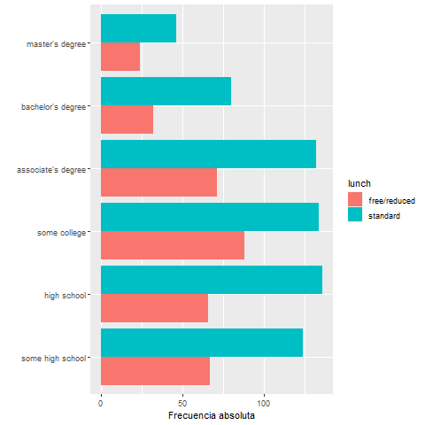

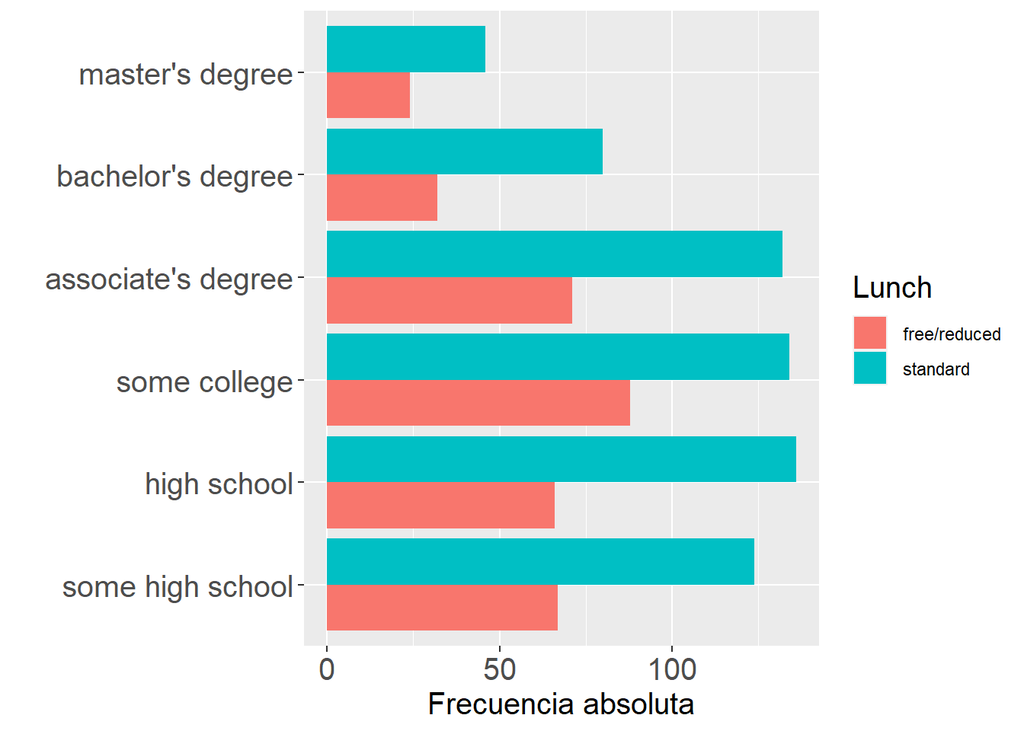

```r
library(ggplot2)
datos %>% ggplot() +
geom_bar(aes(x = factor(`parental level of education`, levels = c("some high school", "high school", "some college",
                                                                  "associate's degree", "bachelor's degree", "master's degree")),
             fill=lunch),
position="dodge") + coord_flip() +
guides(fill = guide_legend(title = "Lunch")) +
labs(x="", y="Frecuencia absoluta") +
theme_gray() +
theme(axis.text = element_text(size=15),
axis.title = element_text(size=15),
legend.title = element_text(size=15))
```

El gráfico muestra que, dependiendo del grado de estudio de los padres, que precio pagan en la comida. La cantidad de precio se separa entre los que tienen precio reducido o gratuito, y precio estándar. esta diferencia se muestra con colores distintos, vistos en la leyenda.

## 1.2 Cuestión 2. **1 punto**

Explica lo que se obtiene en la tibble `df2` y dibuja y analiza el gráfico que se genera en el contexto del problema.

```r
df2<- datos %>%
  tidyr::pivot_longer(
    cols=contains("score"),
    names_to="area", values_to="notas") %>%
  select("area", `test preparation course`, "notas")
```

La tibble df2 se obtiene a partir del conjunto de datos original “datos” y contiene tres columnas: “area”, ‘test preparation course’ y “notas”. La columna “area” contiene el nombre de cada área evaluada (por ejemplo, “math score”), mientras que la columna test preparation course indica si el estudiante tomó o no un curso de preparación para el examen. La columna “notas” contiene las calificaciones obtenidas por cada estudiante en cada área evaluada.

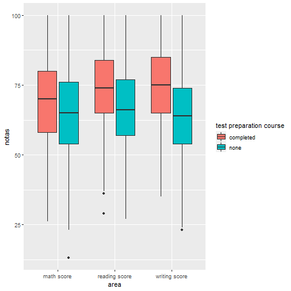

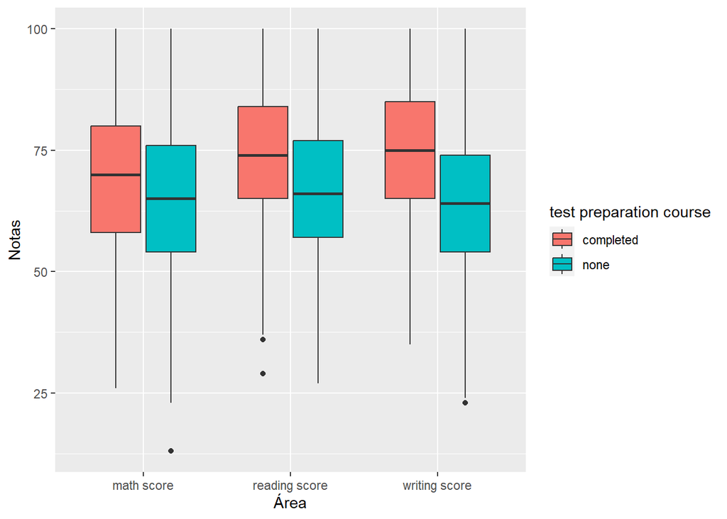

```r
library(tidyverse)
df2 %>%
  ggplot(aes(x = area, y = notas, fill=`test preparation course`), position="dodge") +
  geom_boxplot() +
  labs(x = "Área", y = "Notas") +
  theme(plot.title = element_text(hjust = 0.5))
```

El gráfico compara las notas en cada área (matemáticas, lectura y escritura), dependiendo de si se ha hecho o no el curso preparatorio. Como se observa en la leyenda, un color identifica a las personas que tienen el curso completado, y otro color, a los que no. Del gráfico se puede interpretar que los usuarios que tienen el curso completado tienen un intérvalo de notas mayor que los otros.

## 1.3 Cuestión 3. **1 punto**

Genera el gráfico (con `ggplot2`) e INTERPRETA el siguiente gráfico

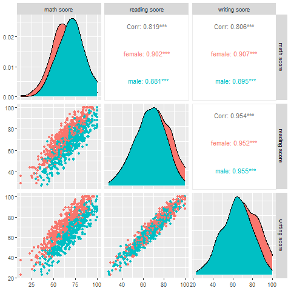

```r
library(GGally)
```

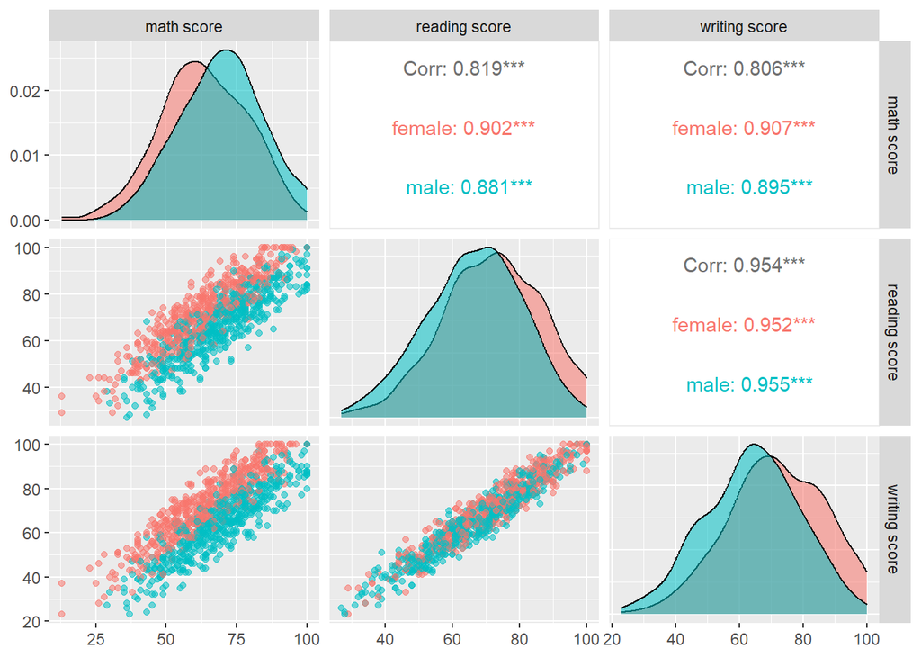

```r
ggpairs(datos,columns = 6:8,aes(color = gender,alpha = 0.5))
```

En el gráfico se compara las notas de las distintas areas (matemáticas, lectura y escritura) dependiendo de el género del estudiante. Viendo los gráficos, podemos interpretar que las notas de los hombres se concentran más alrededor de una nota, en cambio las mujeres, presentan una leve mayor dispersion.

# 2 Parte 2. Estadística Inferencial

Nos piden analizar los datos de la [web de Airbnb](http://insideairbnb.com/get-the-data.html) para Mallorca de septiembre de 2022 y junio de 2022 (se adjuntan) los ficheros .

Cargad en un `dataframe` los datos del fichero `listings.csv` (descomprimido a partir de `listings.csv.gz`).

Vamos a cargar los datos y seleccionar algunas variables `price, review_scores_rating` y `neighbourhood_cleansed`.

```r
#library(tidyverse)
data_june=readr::read_csv("data/listings_mallorca_june_2022.csv")#
print(object.size(data_june),units="MB",stardard="SI")
```

```
## 47.1 Mb
```

```r
#glimpse(data_june)
gsub(pattern="[\\$]|[,]",replacement="",data_june$price[1:10])
```

```
##  [1] "118.00" "173.00" "120.00" "300.00" "372.00" "195.00" "237.00" "286.00"
##  [9] "135.00" "86.00"
```

```r
as.numeric(gsub(pattern="[\\$]|[,]",replacement="",data_june$price[1:10]))
```

```
##  [1] 118 173 120 300 372 195 237 286 135  86
```

```r
data_june$price=as.numeric(gsub(pattern="[\\$]|[,]",replacement="",data_june$price))
head(data_june$price)
```

```
## [1] 118 173 120 300 372 195
```

```r
class(data_june$price)
```

```
## [1] "numeric"
```

```r
data_june= data_june %>% select(price,review_scores_rating,neighbourhood_cleansed)
glimpse(data_june)
```

```
## Rows: 18,298
## Columns: 3
## $ price                  <dbl> 118, 173, 120, 300, 372, 195, 237, 286, 135, 86…
## $ review_scores_rating   <dbl> 4.73, 4.17, NA, 5.00, 5.00, 4.82, 5.00, 4.90, N…
## $ neighbourhood_cleansed <chr> "Sóller", "Pollença", "Sóller", "Alcúdia", "Mur…
```

## 2.1 Pregunta 1. **1 punto**

1. Calcular una estimación puntual de la media para la variable `price` y el error estándar del estimador.
2. Calcular un intervalo de confianza, al nivel de confianza del 95%, para la variable `price`.

### 2.1.1 Solución

1. En este apartado mostramos la media muestral y el error estándar para la variable `price`.

```r
#media
media = mean(data_june$price)
media
```

```
## [1] 286.2452
```

```r
#buscamos el tamaño muestral
n = length(data_june$price)
#error estándar
error = sd(data_june$price)/sqrt(n)
error
```

```
## [1] 6.333008
```

2. Calculamos para la variable `price` un intérvalo de confianza con un nivel de confianza del 95%

```r
#sacamos alpha con el nivel de confianza
alpha = 1-0.95
#conociendo alpha podemos calcular el intérvalo
intconf = c(media-qt(1-(alpha/2),df=n-1)*error,media+qt(1-(alpha/2),df=n-1)*error)
intconf
```

```
## [1] 273.8319 298.6585
```

## 2.2 Pregunta 2. **2 puntos**

1. Supongamos que un responsable de Airbnb asegura que el porcentaje de los valores de `review_scores_rating` mayor o igual que 4.5 es del 79.5% . Contrastad esta hipótesis con los datos de Mallorca.
2. Calcular un intervalo de confianza del 95% asociado a este contraste por el método exacto, el de Wilson y el Laplace.

### 2.2.1 Solución

1. Queremos contrastar la siguiente hipótesis:

$$\left\{
\begin{array}{ll}
H_{0}: & \mu=4.5\\
H_{1}: & \mu>4.5
\end{array}
\right.$$
Dentro de nuestros datos, comprobamos si la variable ‘review_scores_rating’ cumple con los parámetros asegurados por el responsable mediante el t.test.

```r
n = length(data_june$review_scores_rating)
##n
media = mean(data_june$review_scores_rating)
##media
t.test(data_june$review_scores_rating, mu=4.5, alternative="greater", conf.level=0.95)
```

```
##
##  One Sample t-test
##
## data:  data_june$review_scores_rating
## t = 26.817, df = 12662, p-value < 2.2e-16
## alternative hypothesis: true mean is greater than 4.5
## 95 percent confidence interval:
##  4.635406      Inf
## sample estimates:
## mean of x
##  4.644254
```

Dado los resultados del test podemos ver que el p-valor es muy pequeño por lo tanto RECHAZAMOS la hipotesis nula de que
$$\mu=4.5$$

2. En este apartado realizamos el cálculo del intérvalo solicitado mediante los tres métodos. Cada uno se realiza con una llamada a una función diferente de epitools.

Método exacto:

```r
epitools::binom.exact(table(data_june$review_scores_rating>4.5)["TRUE"],length(data_june$review_scores_rating),conf.level = 0.95)
```

```
##         x     n proportion     lower     upper conf.level
## TRUE 9565 18298  0.5227347 0.5154671 0.5299951       0.95
```

Método Wilson:

```r
epitools::binom.wilson(table(data_june$review_scores_rating>4.5)["TRUE"],length(data_june$review_scores_rating),conf.level = 0.95)
```

```
##         x     n proportion     lower     upper conf.level
## TRUE 9565 18298  0.5227347 0.5154936 0.5299663       0.95
```

Método Laplace:

```r
epitools::binom.approx(table(data_june$review_scores_rating>4.5)["TRUE"],length(data_june$review_scores_rating), conf.level = 0.95)
```

```
##         x     n proportion     lower     upper conf.level
## TRUE 9565 18298  0.5227347 0.5154976 0.5299719       0.95
```

## 2.3 Pregunta 3. **2 puntos**

Considera ahora los datos de `price` para del mes junio de 2022 de las dos zonas de Mallorca con más apartamentos vacacionales

```r
sort(table(data_june$neighbourhood_cleansed),decreasing = TRUE)[1:4]
```

```
##
##          Pollença Palma de Mallorca           Alcúdia          Santanyí
##              2625              1923              1897              1015
```

1. Decidid si las varianzas del precio en las dos zonas son iguales o diferentes. Considera que las distribuciones de los valores de precio en las poblaciones son normales.
2. Dad un intervalo de confianza del 95% para comparar las varianzas. Interpretar adecuadamente el resultado.

### 2.3.1 Solución

1. Plantearemos el siguiente contraste:

$$\left\{
\begin{array}{ll}
H_{0}: & \sigma_1=\sigma_2\\
H_{1}: & \sigma_1\ne \sigma_2
\end{array}
\right.$$

```r
# Seleccionar solo los datos de las dos zonas de interés
palma <- data_june[data_june$neighbourhood_cleansed == "Palma de Mallorca",]
pollença <- data_june[data_june$neighbourhood_cleansed == "Pollença",]

# Realizar la prueba de igualdad de varianzas
resultado <- var.test(palma$price, pollença$price)

# Imprimir el resultado
resultado
```

```
##
##  F test to compare two variances
##
## data:  palma$price and pollença$price
## F = 1.6946, num df = 1922, denom df = 2624, p-value < 2.2e-16
## alternative hypothesis: true ratio of variances is not equal to 1
## 95 percent confidence interval:
##  1.559716 1.842243
## sample estimates:
## ratio of variances
##           1.694644
```

Dado el resultado del test podemos observar que el p-valor es muy pequeño por lo tanto rechazamos la hipótesis nula de que las varianzas son iguales.

b)Intervalo de confianza del 95% para comparar las varianzas

```r
# Seleccionar solo los datos de las dos zonas de interés
palma <- data_june[data_june$neighbourhood_cleansed == "Palma de Mallorca",]
pollença <- data_june[data_june$neighbourhood_cleansed == "Pollença",]

# Realizar la prueba de igualdad de varianzas
resultado <- var.test(palma$price, pollença$price)

# Imprimir el resultado
resultado$conf.int
```

```
## [1] 1.559716 1.842243
## attr(,"conf.level")
## [1] 0.95
```

## 2.4 Pregunta 4. **2 puntos**

1. A partir de los resultados del apartado anterior contrastad la hipótesis de que los precios medios en las dos ciudades son iguales contra que son distintos.
2. Calcular un intervalo de confianza del 95% para la diferencia de precios.

### 2.4.1 Solución

Planteamos el siguiente contraste para la resolución del problema:
$$\left\{
\begin{array}{ll}
H_{0}: & \mu_0=\mu_1\\
H_{1}: & \mu_0\ne \mu_1
\end{array}
\right.$$

1. Para poder contrastar tansolo los precios medios de Palma de Mallorca y Pollença deberemos guardar estos datos en variables distintas. Finalmente, para realizar el contraste usaremos la función t.test.

```r
# Seleccionar solo los datos de las dos zonas de interés
palma <- data_june[data_june$neighbourhood_cleansed == "Palma de Mallorca",]
pollença <- data_june[data_june$neighbourhood_cleansed == "Pollença",]

# Realizar la prueba de igualdad de varianzas
resultado <- t.test(palma$price, pollença$price, alternative="two.sided",var.equal = FALSE)

# Imprimir el resultado
resultado
```

```
##
##  Welch Two Sample t-test
##
## data:  palma$price and pollença$price
## t = -10.041, df = 3468.2, p-value < 2.2e-16
## alternative hypothesis: true difference in means is not equal to 0
## 95 percent confidence interval:
##  -122.47995  -82.46299
## sample estimates:
## mean of x mean of y
##  204.0447  306.5162
```

```r
# Seleccionar solo los datos de las dos zonas de interés
palma <- data_june[data_june$neighbourhood_cleansed == "Palma de Mallorca",]
pollença <- data_june[data_june$neighbourhood_cleansed == "Pollença",]

# Realizar la prueba de igualdad de varianzas
resultado <- t.test(palma$price, pollença$price, alternative="two.sided",var.equal = FALSE)

# Imprimir el resultado
resultado$conf.int
```

```
## [1] -122.47995  -82.46299
## attr(,"conf.level")
## [1] 0.95
```